# Climate Health and decent work Nexus

Compiled risk in Brazilian AG

Author

Edgar Rodriguez-Huerta

Published

November 12, 2025

Modified

November 12, 2025

[interactive chart not shown]

# BACKGROUND

**Between 2003 and 2024, more than 54,000 workers were rescued from analogous conditions to slavery in rural areas of Brazil**

**Livestock, sugarcane, and other are among sectors with higher risk**

# LABOUR INSPECTIONS

Brazil is among the few countries that publish open state labour inspection data on workers identified rural areas and removed from the conditions of modern slavery, and it has taken a leading role in addressing this issue.

*Inadequate water, sanitation, and hygiene (WASH), accommodation, excessive overtime, and severe and unexplained wage deductions have emerged* as main issues

### **inadequate WASH**

“There are generally no good quality drinking water, or toilet facilities on the properties. Water for cooking and drinking is often taken from the same streams in which the workers wash themselves, their clothes, cooking utensils and work tools. Furthermore, the rains wash the pesticides used on pastures into those same streams.”

## WASH

### **Climate change and health**

“Workers are among those most exposed to climate change hazards, yet frequently have no choice but to continue working, even if conditions are dangerous. Global occupational safety and health (OSH) protections have struggled to keep up with the evolving risks from climate change, resulting in worker mortality and morbidity.”

### **conclusions**

*Secondary data analysis needs primary data and local knowledge.*

edgarodriguez

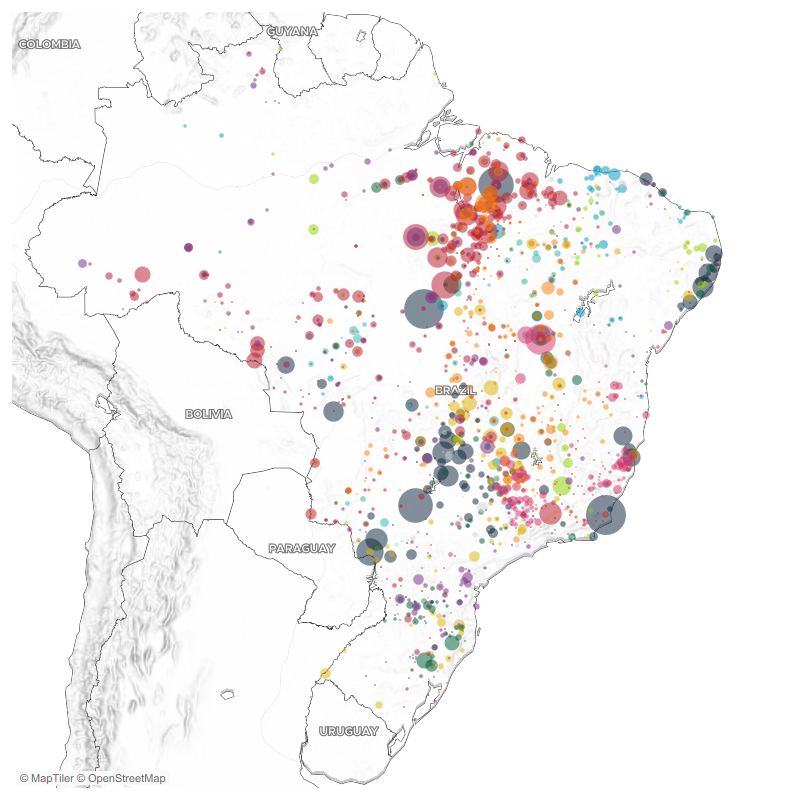

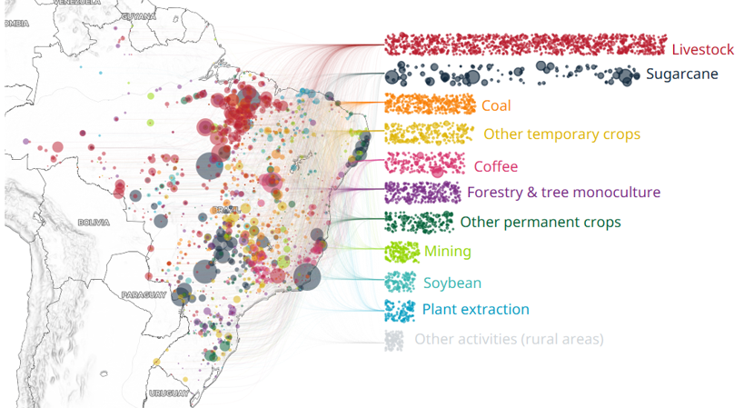

inadequate water, sanitation, and hygiene (WASH), accommodation, excessive overtime, and severe and unexplained wage deductions have emerged as main issues